# RV217 - Exploratory Stats

Bryan Mayer

2021-05-22

# Setup

```r
suppressPackageStartupMessages({
  library(tidyverse)
  library(kableExtra)
})

theme_set(theme_bw())

rv217 = read_csv("../../data/RV217Clean.csv")  %>%
  subset(ID != 40320) # only one data point and no APTIMA info
pretty_pvalues = function (pvalues, digits = 3,
                           lower_cutoff = 0.001, missing_char = "---",
    include_p = FALSE, trailing_zeros = TRUE)
{
    missing_p = which(is.na(pvalues))
    below_cutoff_p = which(pvalues < lower_cutoff)
    pvalues_new = round(pvalues, digits = digits)

    pvalues_new[missing_p] = missing_char
    pvalues_new[below_cutoff_p] = paste0("<", lower_cutoff)

    pvalues_new
}
```

# APTIMA diagnosis

```r
rv217 %>%
  subset(days_dx == 0) %>%
  mutate(
    APTIMA_levels = case_when(
      is.na(APTIMA) ~ "Missing APTIMA",
      !is.na(APTIMA_num) ~ "Numerical measurement",
      is.na(suppressWarnings(as.numeric(APTIMA))) ~ APTIMA
    )
    ) %>%
  group_by(APTIMA_levels) %>%
  summarize(
    N = n(),
    Total_Obs_VL = sum(!is.na(log10VL))
  ) %>%
  arrange(desc(N)) %>%
  janitor::adorn_totals() %>%
  kable(caption = "APTIMA Reading Output at APTIMA Diagnosis") %>%
  kable_styling(full_width = F)
```

APTIMA Reading Output at APTIMA Diagnosis

| APTIMA_levels | N | Total_Obs_VL |
| --- | --- | --- |
| Numerical measurement | 43 | 6 |
| R | 7 | 0 |
| Missing APTIMA | 2 | 2 |
| NR | 1 | 1 |
| R/NR | 1 | 0 |
| Total | 54 | 9 |

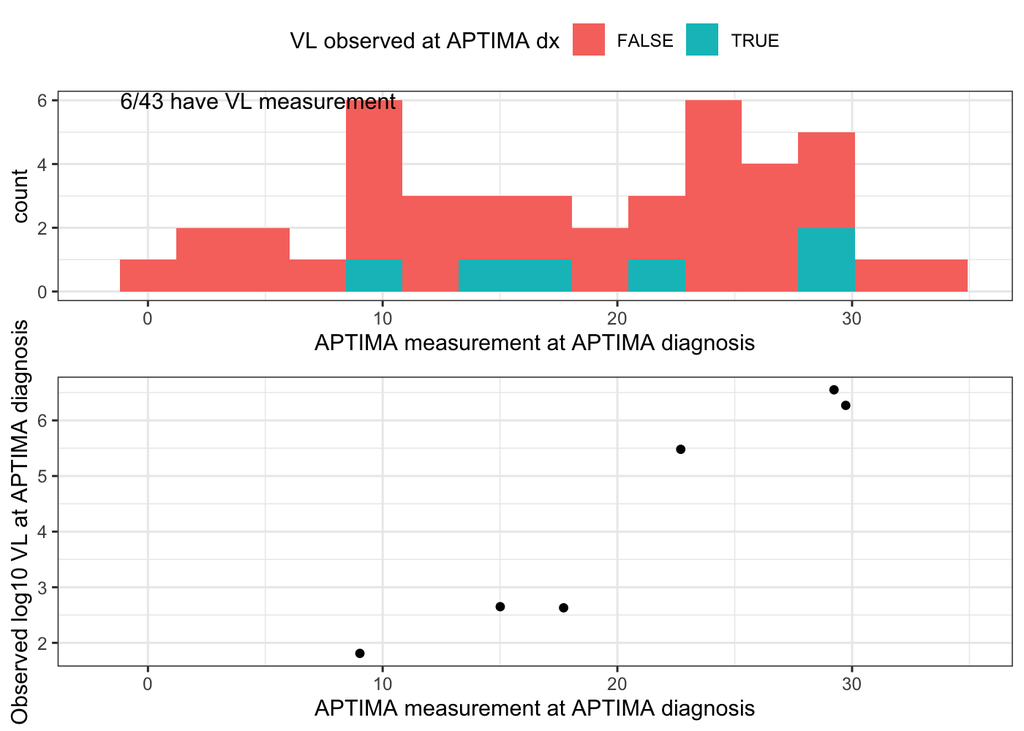

```r
pl1 = rv217 %>%
  subset(days_dx == 0 & !is.na(APTIMA_num)) %>%
  mutate(VL_obs = !is.na(log10VL)) %>%
  ggplot(aes(x = APTIMA_num)) +
  #geom_histogram(bins = 15) +
  geom_histogram(bins = 15, aes(fill = factor(VL_obs))) +
  scale_x_continuous("APTIMA measurement at APTIMA diagnosis") +
  theme(legend.position = "top") +
  annotate("text", x = 0, y = Inf, label = "6/43 have VL measurement", hjust = 0.1, vjust = 1.1) +
  coord_cartesian(xlim = c(-2, 35)) +
  labs(fill = "VL observed at APTIMA dx")

pl2 = rv217 %>%
  subset(days_dx == 0 & !is.na(log10VL)& !is.na(APTIMA_num)) %>%
  ggplot(aes(y = log10VL, x = APTIMA_num)) +
  geom_point() +
  scale_x_continuous("APTIMA measurement at APTIMA diagnosis") +
  coord_cartesian(xlim = c(-2, 35)) +
  scale_y_continuous("Observed log10 VL at APTIMA diagnosis")

cowplot::plot_grid(pl1, pl2, align = "v", nrow = 2)
```

# APTIMA vs. VL

## Overall

Moderate correlation (repeated measures adjusted) between APTIMA and log10 viral load; that is higher with log10 APTIMA.

```r
cor_apt_vl = rv217 %>%
  select(ID, VL, log10VL, APTIMA_num) %>%
  na.omit() %>% # complete case subsetting but not actually necessary
  mutate(ID = factor(ID), log10_APTIMA = log10(APTIMA_num)) %>%
  gather(vl_trans, vl, VL, log10VL) %>%
  gather(aptima_trans, aptima, APTIMA_num, log10_APTIMA) %>%
  group_by(vl_trans, aptima_trans) %>%
  nest() %>%
  mutate(
    rmcorr_mod = map(data, ~rmcorr::rmcorr(ID, vl, aptima, .x)),
    rmcorr_res = map(rmcorr_mod, ~tibble(r = .x$r, pvalue = .x$p, CI_lower = .x$CI[1], CI_upper = .x$CI[2]))
    ) %>%
  unnest(rmcorr_res)

cor_apt_vl %>%
  ungroup() %>%
  mutate_if(is.numeric, round, 3) %>%
  mutate(Correlation_95CI = paste0(r, " (", CI_lower, ", ", CI_upper,")")) %>%
  select(vl_trans, aptima_trans, Correlation_95CI, pvalue) %>%
  mutate(
    vl_trans = if_else(vl_trans == "VL", "Raw", "log10"),
    aptima_trans = if_else(aptima_trans == "APTIMA_num", "Raw", "log10")
    ) %>%
  arrange(vl_trans)  %>%
  kable(caption = "Correlation between APTIMA and VL overall") %>%
  kable_styling(full_width = F)
```

Correlation between APTIMA and VL overall

| vl_trans | aptima_trans | Correlation_95CI | pvalue |
| --- | --- | --- | --- |
| log10 | Raw | 0.367 (0.259, 0.467) | 0.000 |
| log10 | log10 | 0.404 (0.299, 0.5) | 0.000 |
| Raw | Raw | 0.002 (-0.118, 0.122) | 0.970 |
| Raw | log10 | 0.018 (-0.102, 0.137) | 0.771 |

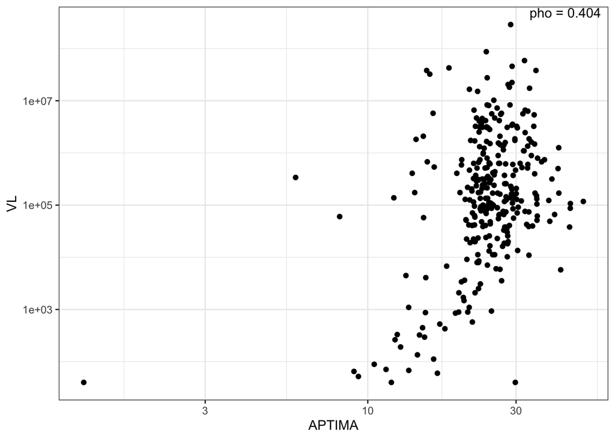

```r
rv217 %>%
  subset(!is.na(log10VL) & !is.na(APTIMA_num)) %>%
  ggplot(aes(y = VL, x = APTIMA_num)) +
  geom_point() +
  scale_y_log10("VL") +
  scale_x_log10("APTIMA") +
  annotate("text", x = Inf, y = Inf, label = paste0("pho = ", round(cor_apt_vl$r[4], 3)),
    vjust = 1.1,
    hjust = 1.1
  )
```

## At first positive VL

Correlation is even higher at first positive viral load (when removing the participant with APTIMA = 3). Visually, the correlation worsens when APTIMA > 30.

```r
# spearman is transform invariant

cor_apt_vl_1stpos = rv217 %>%
  subset(days == 0 & APTIMA_num > 3) %>%
  select(ID, VL, log10VL, APTIMA_num) %>%
  na.omit() %>% # complete case subsetting but not actually necessary
  mutate(
    ID = factor(ID),
    log10_APTIMA = log10(APTIMA_num),
    spearman_cor = cor(APTIMA_num, VL, method = "spearman", use = "complete.obs"),
    spearman_p = coin::pvalue(coin::spearman_test(APTIMA_num ~ VL))
    ) %>%
  gather(vl_trans, vl, VL, log10VL) %>%
  gather(aptima_trans, aptima, APTIMA_num, log10_APTIMA) %>%
  group_by(vl_trans, aptima_trans, spearman_cor, spearman_p) %>%
  summarize(
    pearson_cor = cor(aptima, vl, use = "complete.obs"),
    pearson_p = cor.test(aptima, vl)$p.value
    )
cor_apt_vl_1stpos %>%
  ungroup() %>%
  mutate_if(is.numeric, round, 3) %>%
  select(vl_trans, aptima_trans, everything()) %>%
  mutate(
    vl_trans = if_else(vl_trans == "VL", "Raw", "log10"),
    aptima_trans = if_else(aptima_trans == "APTIMA_num", "Raw", "log10")
    ) %>%
  arrange(vl_trans)  %>%
  kable(caption = "Correlation between APTIMA and VL at first positive VL (APTIMA > 5)") %>%
  kable_styling(full_width = F) %>%
  collapse_rows(3:4)
```

Correlation between APTIMA and VL at first positive VL (APTIMA > 5)

| vl_trans | aptima_trans | spearman_cor | spearman_p | pearson_cor | pearson_p |
| --- | --- | --- | --- | --- | --- |
| log10 | Raw | 0.83 | <2.220446e-16 | 0.805 | 0.000 |
| log10 | log10 |  |  | 0.840 | 0.000 |
| Raw | Raw |  |  | 0.336 | 0.034 |
| Raw | log10 |  |  | 0.340 | 0.032 |

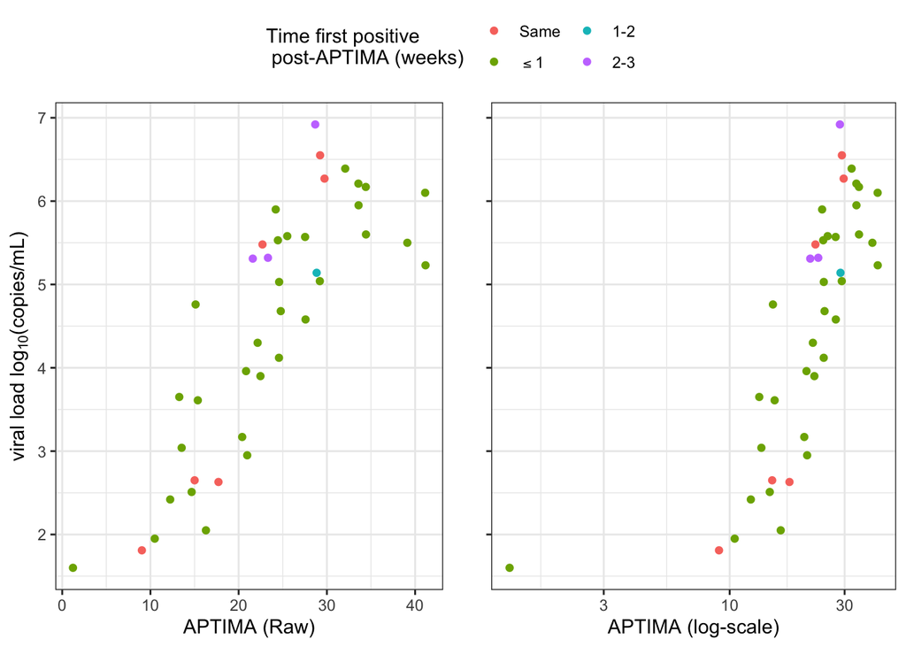

```r
# rv217 %>%
#   subset(days == 0) %>%
#   select(ID, VL, log10VL, APTIMA_num) %>%
#   na.omit() %>%
#   ggplot(aes(x = APTIMA_num, y = log10VL)) +
#   scale_x_continuous("APTIMA") +
#   scale_y_log10() +
#   geom_point()

pl_log = rv217 %>%
  subset(days == 0) %>%
  mutate(days_post_aptima = days_dx/7 - days/7) %>%
  select(ID, VL, log10VL, APTIMA_num, days_post_aptima) %>%
  na.omit() %>%
  ggplot(aes(x = APTIMA_num, y = log10VL,
             colour = cut(days_post_aptima, breaks = -1:3,
                          labels = 1:4, include.lowest = F))) +
  scale_x_log10("APTIMA (log-scale)") +
  scale_y_continuous() +
  labs(colour = "Time first positive \n post-APTIMA (weeks)",
              y = ""
       )+
  geom_point() +
  guides(col = guide_legend(nrow = 2)) +
  scale_color_discrete(
    breaks = 1:4,
    labels = c("Same", bquote("" <= 1), "1-2", "2-3")
    ) +
  theme(legend.position = "top")

pl = rv217 %>%
  subset(days == 0) %>%
  mutate(days_post_aptima = days_dx/7 - days/7) %>%
  select(ID, VL, log10VL, APTIMA_num, days_post_aptima) %>%
  na.omit() %>%
  ggplot(aes(x = APTIMA_num, y = log10VL,
             colour = cut(days_post_aptima, breaks = -1:3,
                          labels = 1:4, include.lowest = F))) +
  scale_x_continuous("APTIMA (Raw)") +
  scale_y_continuous(expression(paste("viral load log"[10],"(copies/mL)"))) +
  labs(colour = "weeks_post_dx") +
  geom_point() +
  theme(legend.position = "none")

vl_aptima_scatter = cowplot::plot_grid(cowplot::get_legend(pl_log),
                   cowplot::plot_grid(pl + theme(),
                                       pl_log+theme(legend.position = "none",
                                                    axis.text.y = element_blank())
                                     ),
                   rel_heights = c(2, 12), nrow = 2)
#%>%
#  cowplot::add_sub("APTIMA measurement") %>%
#  cowplot::ggdraw()
vl_aptima_scatter
```

## Modeling

The APTIMA value of 3 was removed because it is in a very sparse region.

Transformations could be compared via AIC within the same data set. Root MSE depicts the absolute error of prediction on the scale of log10 VL. The untransformated aptima input usually has the lowest mse but results are pretty similar.

The final model chosen by minimum prediction error was using APTIMA within [9, 34]. This range covers the upper range of the APTIMA values observed at diagnosis (without viral load) but is slightly higher than the lower range there.

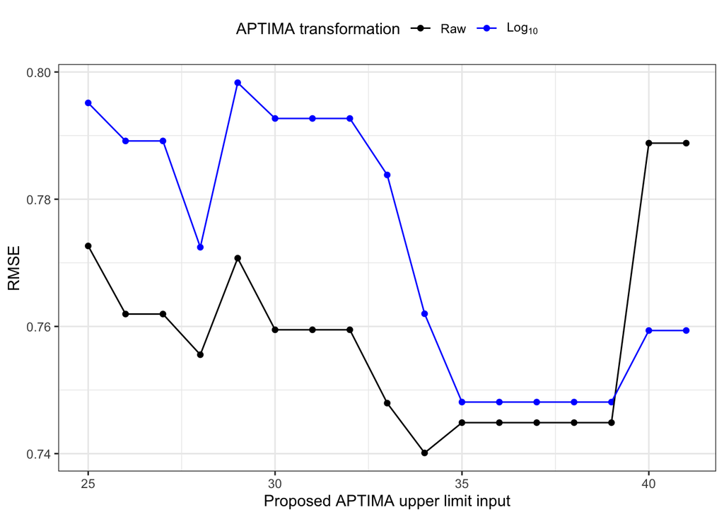

```r
mod_data = rv217 %>%
  subset(days == 0) %>%
  select(ID, VL, log10VL, APTIMA_num) %>%
  na.omit() %>% # complete case subsetting but not actually necessary
  mutate(
    ID = factor(ID),
    log10_APTIMA = log10(APTIMA_num)
  )

mod_mse = map_df(25:max(mod_data$APTIMA_num), function(i){
  map_df(c("APTIMA_num", "log10_APTIMA"), function(j){
    #map_df(9:10, function(k){ # lower limit of 9 is dominant
      form = as.formula(paste("log10VL ~ ", j))
      mod =  eval(bquote(lm(
        .(form), data = subset(mod_data, APTIMA_num >= 9 &
                                 APTIMA_num <= i)
      )))
      broom::tidy(mod) %>%
        mutate(
          term = janitor::make_clean_names(term),
          term = if_else(term != "intercept", "aptima", term)
        ) %>%
        select(term, estimate) %>%
        pivot_wider(names_from = term, values_from = estimate) %>%
        mutate(
          aptima_trans = j,
          #lower_limit = k,
          upper_limit = i,
          rmse = sqrt(mean(mod$residuals ^ 2))
        )
    #})
  })
})

rmse_pl = ggplot(mod_mse, aes(x = upper_limit, colour = aptima_trans, y = rmse)) +
  geom_point() +
  geom_line() +
  labs(y = "RMSE", x = "Proposed APTIMA upper limit input", colour = "APTIMA transformation") +
  scale_color_manual(breaks = c("APTIMA_num", "log10_APTIMA"),
                       labels = c("Raw", bquote("Log"[10])),
                     values = c("black", "blue")) +
  theme(legend.position = "top")


rmse_pl
```

```r
final_mod = lm(log10VL ~ APTIMA_num, data = subset(mod_data, APTIMA_num >= 9 & APTIMA_num <= 34))
pred_res = tibble(
  APTIMA_num = seq(9, 34, by = 0.5),
  log10VL = predict(final_mod, newdata = tibble(APTIMA_num = APTIMA_num)),
  pred_lower = predict(final_mod, newdata = tibble(APTIMA_num = APTIMA_num), interval = "prediction")[,2],
  pred_upper = predict(final_mod, newdata = tibble(APTIMA_num = APTIMA_num), interval = "prediction")[,3]
)
```

```r
broom::tidy(final_mod) %>%
  bind_cols(as_tibble(confint(final_mod))) %>%
  kable(caption = "Final model for log10 VL prediction. About 0.19 increase (1.55-fold) in log10 VL per unit increase in APTIMA when APTIMA is within 9-34.", digits = 3)  %>%
  kable_styling(full_width = F)
```

Final model for log10 VL prediction. About 0.19 increase (1.55-fold) in log10 VL per unit increase in APTIMA when APTIMA is within 9-34.

| term | estimate | std.error | statistic | p.value | 2.5 % | 97.5 % |
| --- | --- | --- | --- | --- | --- | --- |
| (Intercept) | 0.232 | 0.451 | 0.514 | 0.611 | -0.686 | 1.149 |
| APTIMA_num | 0.189 | 0.020 | 9.707 | 0.000 | 0.150 | 0.229 |

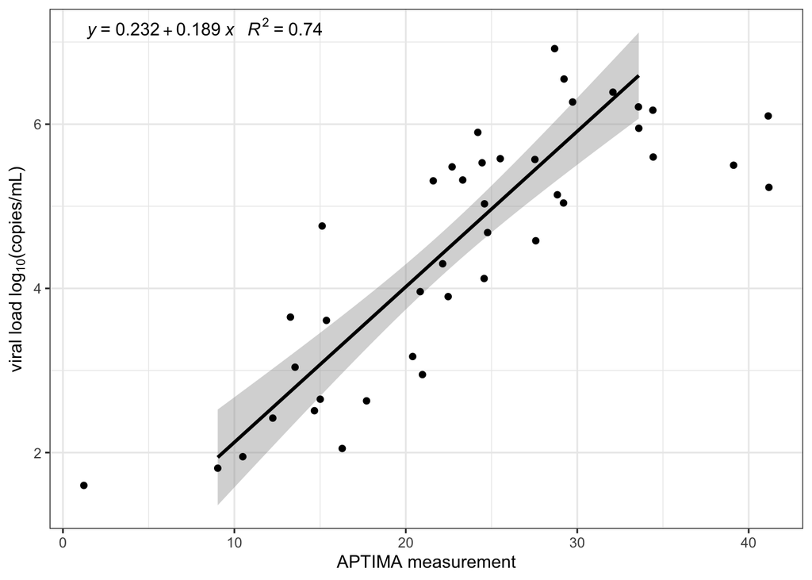

```r
my.formula = y ~ x

final_mod_pl = mod_data %>%
  filter(APTIMA_num >= 9 & APTIMA_num <= 34) %>%
  ggplot(aes(x = APTIMA_num, y = log10VL)) +
  scale_x_continuous("APTIMA measurement") +
  scale_y_continuous(expression(paste("viral load log"[10],"(copies/mL)"))) +
  geom_smooth(data = , method = "lm", formula = my.formula, colour = "black") +
  geom_point(data = mod_data) +
  ggpmisc::stat_poly_eq(formula = my.formula, vjust = 0.2,
                aes(label = paste(..eq.label.., ..rr.label.., sep = "~~~")),
                parse = TRUE) +
  theme(legend.position = "top")


final_mod_pl
```

# Predicting VL at APTIMA dx

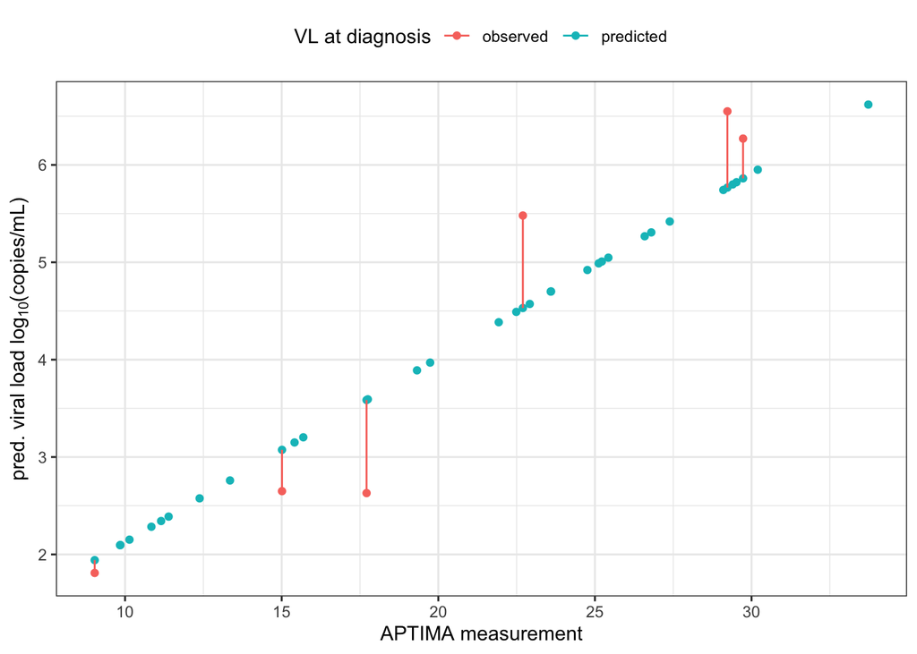

```r
pred_dat = rv217 %>%
  subset(days_dx == 0 & !is.na(APTIMA_num)) %>%
  mutate(
    missing_vl = factor(is.na(log10VL)),
    in_range = factor(APTIMA_num >= 9 & APTIMA_num <= 34),
    pred_log10VL =  predict(final_mod, newdata = tibble(APTIMA_num = APTIMA_num)),
    PI_lower = predict(final_mod,
                         newdata = tibble(APTIMA_num = APTIMA_num),
                         interval = "prediction")[, 2],
    PI_upper = predict(final_mod,
                         newdata = tibble(APTIMA_num = APTIMA_num),
                         interval = "prediction")[, 3]
  )

pred_mod_pl = pred_dat %>%
  select(ID, missing_vl, in_range, log10VL, pred_log10VL, APTIMA_num) %>%
  filter(in_range == TRUE) %>%
  rename(observed = log10VL, predicted = pred_log10VL) %>%
  gather(type, log10VL, observed, predicted) %>%
  ggplot(aes(x = APTIMA_num, y = log10VL)) +
  geom_point(aes(colour = type)) +
  #geom_ribbon(data = pred_res, aes(ymin = pred_lower, ymax = pred_upper),
  #            fill = "grey80", alpha = 0.5, colour = NA) +
  geom_line(aes(group = ID, colour = type)) +
  scale_x_continuous("APTIMA measurement") +
  scale_y_continuous(expression(paste("pred. viral load log"[10],"(copies/mL)"))) +
  labs(colour = "VL at diagnosis") +
  theme(legend.position = "top")

pred_mod_pl
```

```r
predicted_dat = read_csv("../../data/RV217MonoVLPred.csv")
```

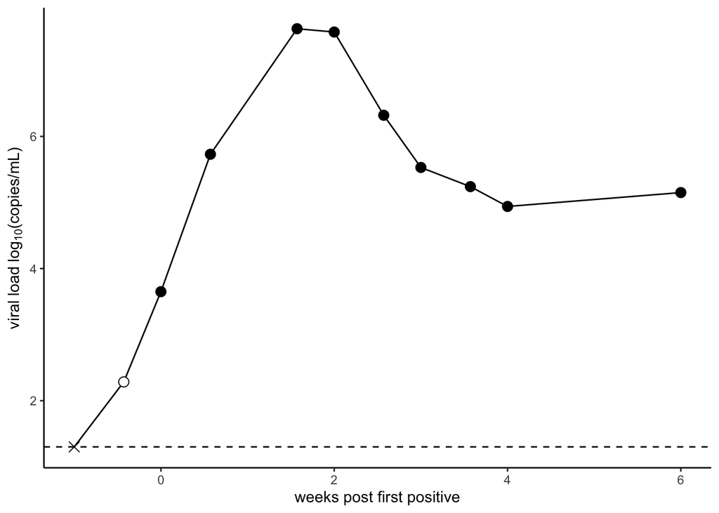

```r
pred_pl = predicted_dat %>%
  filter(ID == "10739") %>%
  mutate(
    log10VL_pred = if_else(days == -7, log10(20), log10VL_pred),
    pch_cat = if_else(days == -7, 2, 1 * predicted_VL)
    ) %>%
  filter(!is.na(log10VL_pred)) %>%
  select(days, log10VL_pred, pch_cat) %>%
  ggplot(aes(x = days/7, y = log10VL_pred)) +
  geom_line() +
  geom_point(aes(shape = factor(pch_cat), fill = factor(pch_cat == 1)), size = 3) +
  scale_shape_manual(values = c(21, 21, 4)) +
  scale_fill_manual(values = c("black", "white")) +
  geom_hline(yintercept = log10(20), linetype = "dashed") +
  labs(x = "weeks post first positive",
       y = expression(paste("viral load log"[10],"(copies/mL)"))) +
  theme_classic() +
  theme(legend.position = "none")

pred_pl
```

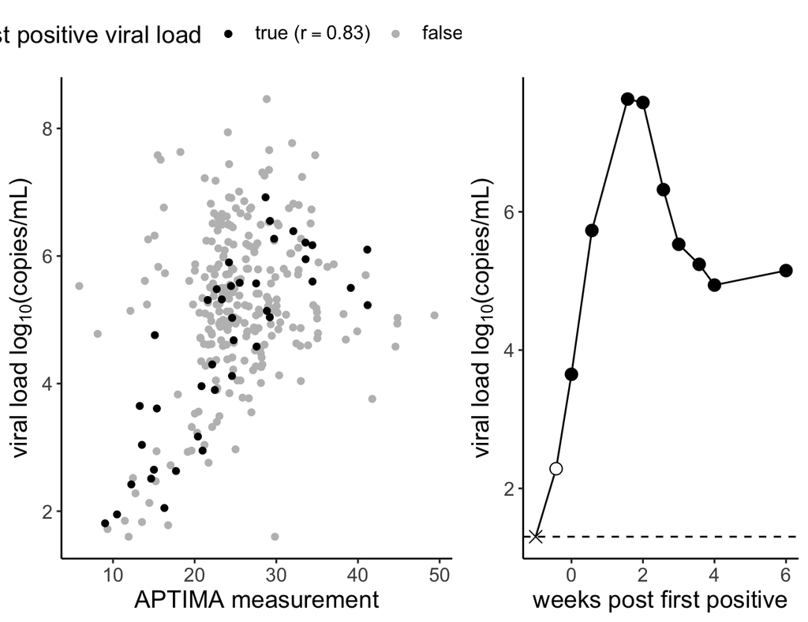

```r
cor_tab_all = rv217 %>%
  subset(APTIMA_num > 3) %>%
  select(ID, VL, log10VL, APTIMA_num) %>%
  na.omit() %>% # complete case subsetting but not actually necessary
  nest(data = everything()) %>%
  summarize(
    pearson = map(data, ~cor.test(~ APTIMA_num + log10VL, use = "complete.obs",
                                 method = "spearman", data = .) %>% broom::tidy()),
    spearman = map(data, ~cor.test(~ APTIMA_num + log10VL, use = "complete.obs", data = .) %>% broom::tidy()),
    rmcorr = map(data, ~rmcorr::rmcorr(ID, log10VL, APTIMA_num, dataset = .x))
    ) %>%
  gather(type, cor, pearson, spearman) %>%
  unnest(cor) %>%
  mutate(first_pos = "All")


cor_tab = rv217 %>%
  subset(APTIMA_num > 3) %>%
  select(ID, VL, days, log10VL, APTIMA_num) %>%
  mutate(first_pos = as.character(days == 0)) %>%
  na.omit() %>% # complete case subsetting but not actually necessary
  group_by(first_pos) %>%
  nest() %>%
  summarize(
    pearson = map(data, ~cor.test(~ APTIMA_num + log10VL, use = "complete.obs",
                                 method = "spearman", data = .) %>% broom::tidy()),
    spearman = map(data, ~cor.test(~ APTIMA_num + log10VL, use = "complete.obs", data = .) %>% broom::tidy())
    #rmcorr = map(data, ~rmcorr::rmcorr(ID, log10VL, APTIMA_num, dataset = .x))
    )  %>%
  gather(type, cor, pearson, spearman) %>%
  unnest(cor) %>%
  mutate(first_pos = as.character(first_pos)) %>%
  bind_rows(cor_tab_all)

rmcor_postFP = rmcorr::rmcorr(ID, log10VL, APTIMA_num, dataset = subset(rv217, days > 0))


cor_tab_pl = cor_tab %>%
  mutate(p.value = pretty_pvalues(p.value)) %>%
  mutate_if(is.numeric, round, 3) %>%
  unite(estimate, estimate, p.value, sep = " (") %>%
  mutate(estimate = paste0(estimate, ")")) %>%
  select(first_pos, type, estimate) %>%
  pivot_wider(values_from = estimate, names_from = first_pos, names_prefix = "x") %>%
  dplyr::select(` ` = type, `first positive` = xTRUE, overall = xAll) %>%
  mutate(` ` = paste(` `, "\u03C1"))


pl_dat = rv217 %>%
  subset(!is.na(log10VL) & !is.na(APTIMA_num) & APTIMA_num > 3)

tt <- gridExtra::ttheme_default(base_size = 7, padding = unit(c(1, 1), "mm"))
tt$core$fg_params <- list(fontface = matrix(c(1,2,2),
                                          ncol=ncol(cor_tab_pl),nrow=nrow(cor_tab_pl),byrow=TRUE),
                          col = matrix(c("black", "black", "gray50"),
                                          ncol=ncol(cor_tab_pl),nrow=nrow(cor_tab_pl),byrow=TRUE),
                          fontsize = 10)

tt$core$bg_params = list(
                     fill=c(rep("white",3),"white","white"),
                     col=c("white","white","white","grey80","white"),
                     alpha = rep(1,5))

tt$colhead$bg_params = list(fill = "white", col = "white")
tt$colhead$fg_params = list(fontsize = 10, fontface = 1)


cor_pl = ggplot(pl_dat, aes(x = APTIMA_num, y = log10VL, colour = factor(days > 0))) +
  geom_point(data = subset(pl_dat, days > 0)) +
  geom_point(data = subset(pl_dat, days == 0)) +
  scale_y_continuous(breaks = 1:4 * 2) +
  scale_color_manual(values = c("black", "gray"),
                     labels = c(bquote("true ("*r=="0.83)"),
                                bquote("false ("*r=="0.16)"))
                     )+
  labs(x = "APTIMA measurement",
       y = expression(paste("viral load log"[10],"(copies/mL)")),
       colour = "first positive viral load") +
  theme_classic() +
  theme(legend.position = "top", text = element_text(size = 14))
  #annotation_custom(gridExtra::tableGrob(cor_tab_pl, rows = NULL, theme = tt),
  #                  xmin=25, xmax=50, ymin=1.5, ymax=3)

man_pl = cowplot::plot_grid(cor_pl, pred_pl + theme(text = element_text(size = 14)),
                            rel_widths = c(2,1.5), align = "h", axis = "bt")
man_pl
```

```r
ggsave("manuscript_pl.png", man_pl, width = 9, height = 5)

ggsave("fig2.eps", man_pl, width = 9, height = 5)
```

# APTIMA and VL kinetics between dx and first positive

We would expect increasing APTIMA to map increasing VL. This is hard to evaluate pre-first positive because we don’t observe viral loads. Looking after first positive (first two positive measurements), there are quite a few cases where VL and APTIMA are moving in opposite directions (red region of the plot).

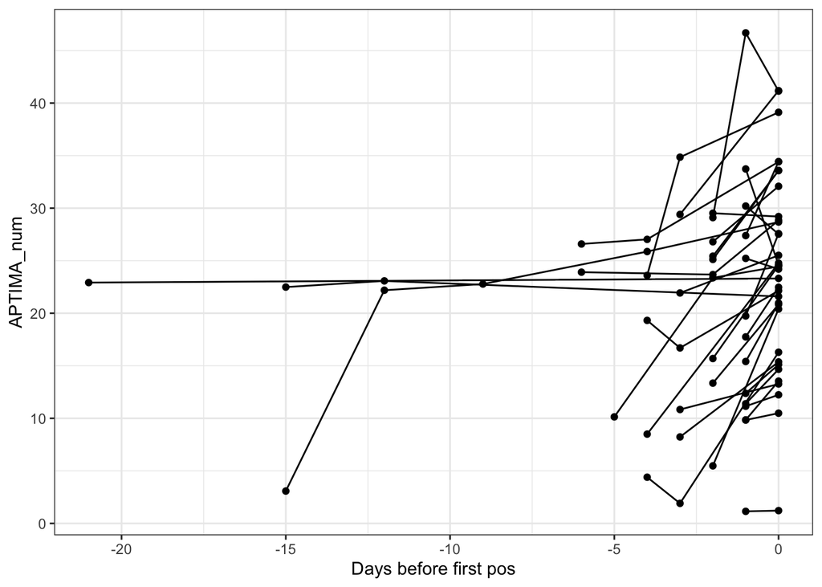

```r
kinetic_dat = rv217 %>%
  subset(days_dx >= 0 & days <= 0 & days != days_dx) %>%
  group_by(ID) %>%
  mutate(
    obsAPTIMA_firstpos = !is.na(APTIMA_num[days == 0]),
    pred_log10VL = predict(final_mod, tibble(APTIMA_num = APTIMA_num))
  ) %>%
  subset(obsAPTIMA_firstpos)

kinetic_dat %>%
  #subset(days > -5) %>%
  ggplot(aes(x = days, y = APTIMA_num)) +
  geom_point() +
  geom_line(aes(group = ID)) +
  scale_x_continuous("Days before first pos")
```

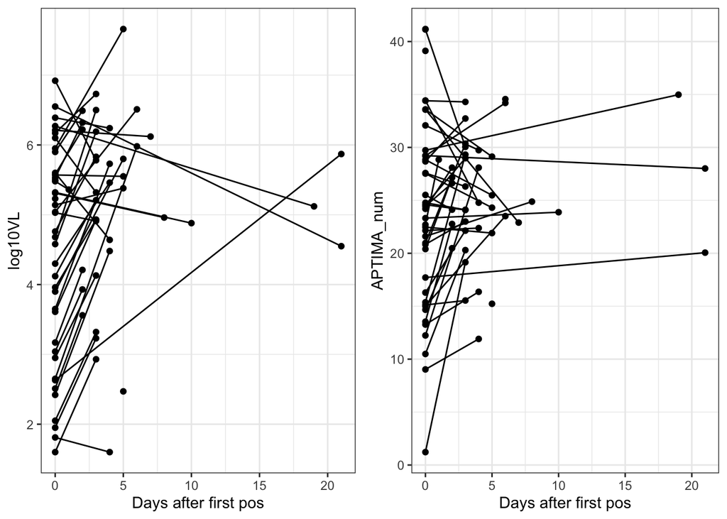

```r
post_firstpos = rv217 %>%
  group_by(ID) %>%
  subset(!is.na(APTIMA_num)) %>%
  mutate(first_two = days == 0 | days == min(days[days > 0])) %>%
  subset(first_two) %>%
  mutate(
    day_cat = factor(days == 0, levels = c(T, F), labels = c("first_pos", "second_pos")),
    pred_log10VL = predict(final_mod, tibble(APTIMA_num = APTIMA_num)),
    second_day = max(days)
    ) %>%
  select(ID, days, second_day, day_cat, APTIMA_num, log10VL, pred_log10VL)

pl1 = post_firstpos %>%
  ggplot(aes(x = days, y = log10VL)) +
  geom_point() +
  geom_line(aes(group = ID)) +
  scale_x_continuous("Days after first pos")

pl2 = post_firstpos %>%
  ggplot(aes(x = days, y = APTIMA_num)) +
  geom_point() +
  geom_line(aes(group = ID)) +
  scale_x_continuous("Days after first pos")

cowplot::plot_grid(pl1, pl2)
```

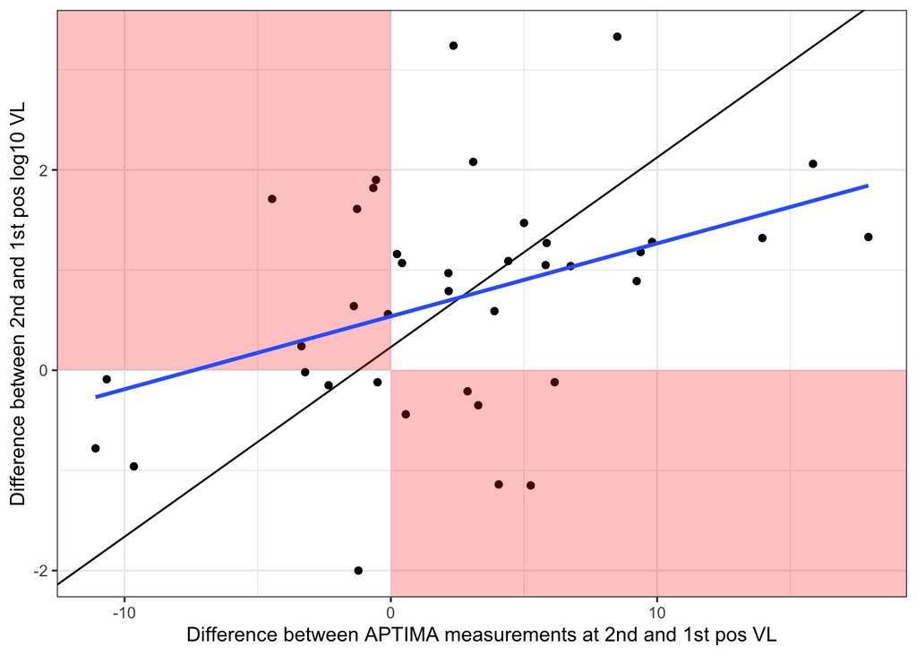

```r
post_firstpos %>%
  select(ID, log10VL, APTIMA_num, pred_log10VL, day_cat, second_day) %>%
  pivot_wider(names_from = day_cat, values_from = c(log10VL, APTIMA_num, pred_log10VL)) %>%
  mutate(
    log10VL_traj = log10VL_second_pos - log10VL_first_pos,
    APTIMA_traj = APTIMA_num_second_pos - APTIMA_num_first_pos,
    max_APTIMA = max(c(APTIMA_num_second_pos, APTIMA_num_first_pos), na.rm = T),
    min_APTIMA = min(c(APTIMA_num_second_pos, APTIMA_num_first_pos), na.rm = T),
    APTIMA_inrange = factor(min_APTIMA >= 9 & max_APTIMA <= 34),
    pred_log10VL_traj = pred_log10VL_second_pos - pred_log10VL_first_pos
  ) %>%
  ggplot(aes(y = log10VL_traj, x = APTIMA_traj)) +
  geom_point() +
  geom_abline(slope = coef(final_mod)[2], intercept = coef(final_mod)[1]) +
  scale_x_continuous("Difference between APTIMA measurements at 2nd and 1st pos VL") +
  scale_y_continuous("Difference between 2nd and 1st pos log10 VL") +
  #annotate("text", x = 10, y = 2.2, angle = atan(coef(final_mod)[2])*180/pi, vjust = 0, label = "Final model predicted relationship") +
  #annotate("text", x = 10, y = 1.2, angle = 22, label = "Actual relationship", colour = "blue") +
  annotate("rect", xmin = 0, xmax = Inf, ymin = -Inf, ymax = 0, fill = "red", alpha = 0.25) +
  annotate("rect", xmin = -Inf, xmax = 0, ymin = 0, ymax = Inf, fill = "red", alpha = 0.25) +
  geom_smooth(method = "lm", se = F)
```

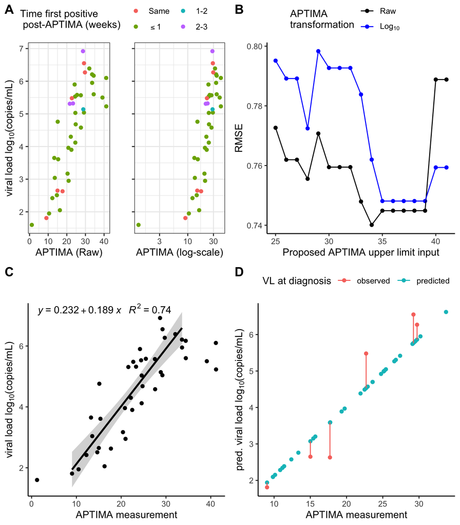

```r
library(cowplot)
theme_set(theme_classic())

supp_topB = cowplot::plot_grid(get_legend(rmse_pl + labs(colour = "APTIMA\ntransformation")+
                                            guides(col = guide_legend(nrow = 2))),
                               rmse_pl + theme(legend.position = "none"), rel_heights = c(2, 12),
                               nrow = 2)

supp_top =cowplot::plot_grid(vl_aptima_scatter, supp_topB,
                   nrow = 1, labels = LETTERS[1:2],
                              align = "h", axis = "t")


supp_bottom = cowplot::plot_grid(final_mod_pl, pred_mod_pl, nrow = 1, align = "h", axis = "bt",
                                 labels = LETTERS[3:4])

cowplot::plot_grid(supp_top, supp_bottom, nrow = 2)
```

```r
ggsave("figS8.eps", cowplot::plot_grid(supp_top, supp_bottom, nrow = 2), width = 8.5, height = 10)


theme_set(theme_bw())
```

# Save predicted data

```r
pred_dat %>%
  select(ID, days, APTIMA_num, log10VL, pred_log10VL, PI_lower, PI_upper) %>%
  rename(days_before_firstVL = days) %>%
  write_csv("../../data/RV217_predictedVLdx.csv")
```